# Part I - ProsperLoan - Analysis of BorrowerAPR and Loan Characteristics

## by Emmanuel Michael - Feb 2023

1. Introduction
2. Preliminary Wrangling
3. Assessing Data
4. Cleaning Data
5. Univariate Exploration
6. Bivariate Exploration
7. Multivariate Exploration
8. Conclusion

## Preliminary Wrangling

```python
# import all packages and set plots to be embedded inline
import numpy as np
import pandas as pd
import matplotlib.pyplot as plt
import seaborn as sb

%matplotlib inline
```

```python
#load and preview the data
loan_data = pd.read_csv("prosperLoanData.csv")
print(loan_data.shape)
loan_data.head()
```

```
(113937, 81)
```

|  | ListingKey | ListingNumber | ListingCreationDate | CreditGrade | Term | LoanStatus | ClosedDate | BorrowerAPR | BorrowerRate | LenderYield | ... | LP_ServiceFees | LP_CollectionFees | LP_GrossPrincipalLoss | LP_NetPrincipalLoss | LP_NonPrincipalRecoverypayments | PercentFunded | Recommendations | InvestmentFromFriendsCount | InvestmentFromFriendsAmount | Investors |
| --- | --- | --- | --- | --- | --- | --- | --- | --- | --- | --- | --- | --- | --- | --- | --- | --- | --- | --- | --- | --- | --- |
| 0 | 1021339766868145413AB3B | 193129 | 2007-08-26 19:09:29.263000000 | C | 36 | Completed | 2009-08-14 00:00:00 | 0.16516 | 0.1580 | 0.1380 | ... | -133.18 | 0.0 | 0.0 | 0.0 | 0.0 | 1.0 | 0 | 0 | 0.0 | 258 |
| 1 | 10273602499503308B223C1 | 1209647 | 2014-02-27 08:28:07.900000000 | NaN | 36 | Current | NaN | 0.12016 | 0.0920 | 0.0820 | ... | 0.00 | 0.0 | 0.0 | 0.0 | 0.0 | 1.0 | 0 | 0 | 0.0 | 1 |
| 2 | 0EE9337825851032864889A | 81716 | 2007-01-05 15:00:47.090000000 | HR | 36 | Completed | 2009-12-17 00:00:00 | 0.28269 | 0.2750 | 0.2400 | ... | -24.20 | 0.0 | 0.0 | 0.0 | 0.0 | 1.0 | 0 | 0 | 0.0 | 41 |
| 3 | 0EF5356002482715299901A | 658116 | 2012-10-22 11:02:35.010000000 | NaN | 36 | Current | NaN | 0.12528 | 0.0974 | 0.0874 | ... | -108.01 | 0.0 | 0.0 | 0.0 | 0.0 | 1.0 | 0 | 0 | 0.0 | 158 |
| 4 | 0F023589499656230C5E3E2 | 909464 | 2013-09-14 18:38:39.097000000 | NaN | 36 | Current | NaN | 0.24614 | 0.2085 | 0.1985 | ... | -60.27 | 0.0 | 0.0 | 0.0 | 0.0 | 1.0 | 0 | 0 | 0.0 | 20 |

5 rows × 81 columns

### What is the structure of your dataset?

> The dataset which is gotten from Prosper, lending platform, contains 113,937 rows with 81 features as columns including Borrower information, Loan information, Borrower's Employment information and Prosper Loan Company information as it relates to the borrower.

### What is/are the main feature(s) of interest in your dataset?

The main goal for analysing this dataset is to determine loan eligibility and favourability for Prosper loans using BorrowersAPR and and ProsperRating.

### What features in the dataset do you think will help support your investigation into your feature(s) of interest?

To make the best use of our dataset for exploratory analysis, we need to reduce the clutter which essentially means choosing the features (columns) that are most likely to give us information about the borrower and the loan company. The features we will be working with to explore our data are listed below:

> **ListingCreationDate**: The date the listing was created.

> **ListingCategory (numeric)**: The category of the listing that the borrower selected when posting their listing: 0 - Not Available, 1 - Debt Consolidation, 2 - Home Improvement, 3 - Business, 4 - Personal Loan, 5 - Student Use, 6 - Auto, 7- Other, 8 - Baby&Adoption, 9 - Boat, 10 - Cosmetic Procedure, 11 - Engagement Ring, 12 - Green Loans, 13 - Household Expenses, 14 - Large Purchases, 15 - Medical/Dental, 16 - Motorcycle, 17 - RV, 18 - Taxes, 19 - Vacation, 20 - Wedding Loans

> **Term**: The length of the loan expressed in months.

> **LoanStatus**: The current status of the loan: Cancelled, Chargedoff, Completed, Current, Defaulted, FinalPaymentInProgress, PastDue. The PastDue status will be accompanied by a delinquency bucket.

> **BorrowerAPR**: The Borrower's Annual Percentage Rate (APR) for the loan.

> **BorrowerRate**: The Borrower's interest rate for this loan.

> **LenderYield**: The Lender yield on the loan. Lender yield is equal to the interest rate on the loan less the servicing fee.

> **ProsperRating (numeric)**: The Prosper Rating assigned at the time the listing was created: 0 - N/A, 1 - HR, 2 - E, 3 - D, 4 - C, 5 - B, 6 - A, 7 - AA. Applicable for loans originated after July 2009.

> **ProsperRating (Alpha)**: The Prosper Rating assigned at the time the listing was created between AA - HR. Applicable for loans originated after July 2009.

> **ProsperScore**: A custom risk score built using historical Prosper data. The score ranges from 1-10, with 10 being the best, or lowest risk score. Applicable for loans originated after July 2009.

> **EmploymentStatus**: The employment status of the borrower at the time they posted the listing.

> **IsBorrowerHomeowner**: A Borrower will be classified as a homowner if they have a mortgage on their credit profile or provide documentation confirming they are a homeowner.

> **TotalCreditLinespast7years**: Number of credit lines in the past seven years at the time the credit profile was pulled.

> **CurrentDelinquencies**: Number of accounts delinquent at the time the credit profile was pulled.

> **AmountDelinquent**: Dollars delinquent at the time the credit profile was pulled.

> **DelinquenciesLast7Years**: Number of delinquencies in the past 7 years at the time the credit profile was pulled.

> **DebtToIncomeRatio**: The debt to income ratio of the borrower at the time the credit profile was pulled. This value is Null if the debt to income ratio is not available. This value is capped at 10.01 (any debt to income ratio larger than 1000% will be returned as 1001%).

> **IncomeRange**: The income range of the borrower at the time the listing was created.

> **IncomeVerifiable**: The borrower indicated they have the required documentation to support their income.

> **StatedMonthlyIncome**: The monthly income the borrower stated at the time the listing was created.

> **LoanOriginalAmount**: The origination amount of the loan.

> **MonthlyLoanPayment**: The scheduled monthly loan payment.

## Data Assessment

The original dataset contains 81 features which is more information than is necessary for our analysis.

In this sections, we will reduce the dataset to only features that will most likely be needed.

We will assess those features to get a clear overview of the dataset we'll be working with to identify potential issues.

We will also clean the dataset to eliminate quality and tidiness issues in the rows and columns for proper analysis.

```python
loan_data.info()
```

```
<class 'pandas.core.frame.DataFrame'>
RangeIndex: 113937 entries, 0 to 113936
Data columns (total 81 columns):
 #   Column                               Non-Null Count   Dtype
---  ------                               --------------   -----
 0   ListingKey                           113937 non-null  object
 1   ListingNumber                        113937 non-null  int64
 2   ListingCreationDate                  113937 non-null  object
 3   CreditGrade                          28953 non-null   object
 4   Term                                 113937 non-null  int64
 5   LoanStatus                           113937 non-null  object
 6   ClosedDate                           55089 non-null   object
 7   BorrowerAPR                          113912 non-null  float64
 8   BorrowerRate                         113937 non-null  float64
 9   LenderYield                          113937 non-null  float64
```

[output cut: 73 more lines]

```python
loan_data.describe()
```

|  | ListingNumber | Term | BorrowerAPR | BorrowerRate | LenderYield | EstimatedEffectiveYield | EstimatedLoss | EstimatedReturn | ProsperRating (numeric) | ProsperScore | ... | LP_ServiceFees | LP_CollectionFees | LP_GrossPrincipalLoss | LP_NetPrincipalLoss | LP_NonPrincipalRecoverypayments | PercentFunded | Recommendations | InvestmentFromFriendsCount | InvestmentFromFriendsAmount | Investors |
| --- | --- | --- | --- | --- | --- | --- | --- | --- | --- | --- | --- | --- | --- | --- | --- | --- | --- | --- | --- | --- | --- |
| count | 1.139370e+05 | 113937.000000 | 113912.000000 | 113937.000000 | 113937.000000 | 84853.000000 | 84853.000000 | 84853.000000 | 84853.000000 | 84853.000000 | ... | 113937.000000 | 113937.000000 | 113937.000000 | 113937.000000 | 113937.000000 | 113937.000000 | 113937.000000 | 113937.000000 | 113937.000000 | 113937.000000 |
| mean | 6.278857e+05 | 40.830248 | 0.218828 | 0.192764 | 0.182701 | 0.168661 | 0.080306 | 0.096068 | 4.072243 | 5.950067 | ... | -54.725641 | -14.242698 | 700.446342 | 681.420499 | 25.142686 | 0.998584 | 0.048027 | 0.023460 | 16.550751 | 80.475228 |
| std | 3.280762e+05 | 10.436212 | 0.080364 | 0.074818 | 0.074516 | 0.068467 | 0.046764 | 0.030403 | 1.673227 | 2.376501 | ... | 60.675425 | 109.232758 | 2388.513831 | 2357.167068 | 275.657937 | 0.017919 | 0.332353 | 0.232412 | 294.545422 | 103.239020 |
| min | 4.000000e+00 | 12.000000 | 0.006530 | 0.000000 | -0.010000 | -0.182700 | 0.004900 | -0.182700 | 1.000000 | 1.000000 | ... | -664.870000 | -9274.750000 | -94.200000 | -954.550000 | 0.000000 | 0.700000 | 0.000000 | 0.000000 | 0.000000 | 1.000000 |
| 25% | 4.009190e+05 | 36.000000 | 0.156290 | 0.134000 | 0.124200 | 0.115670 | 0.042400 | 0.074080 | 3.000000 | 4.000000 | ... | -73.180000 | 0.000000 | 0.000000 | 0.000000 | 0.000000 | 1.000000 | 0.000000 | 0.000000 | 0.000000 | 2.000000 |
| 50% | 6.005540e+05 | 36.000000 | 0.209760 | 0.184000 | 0.173000 | 0.161500 | 0.072400 | 0.091700 | 4.000000 | 6.000000 | ... | -34.440000 | 0.000000 | 0.000000 | 0.000000 | 0.000000 | 1.000000 | 0.000000 | 0.000000 | 0.000000 | 44.000000 |
| 75% | 8.926340e+05 | 36.000000 | 0.283810 | 0.250000 | 0.240000 | 0.224300 | 0.112000 | 0.116600 | 5.000000 | 8.000000 | ... | -13.920000 | 0.000000 | 0.000000 | 0.000000 | 0.000000 | 1.000000 | 0.000000 | 0.000000 | 0.000000 | 115.000000 |
| max | 1.255725e+06 | 60.000000 | 0.512290 | 0.497500 | 0.492500 | 0.319900 | 0.366000 | 0.283700 | 7.000000 | 11.000000 | ... | 32.060000 | 0.000000 | 25000.000000 | 25000.000000 | 21117.900000 | 1.012500 | 39.000000 | 33.000000 | 25000.000000 | 1189.000000 |

8 rows × 61 columns

```python
loan_data['IncomeRange'].value_counts()
```

```
$25,000-49,999    32192
$50,000-74,999    31050
$100,000+         17337
$75,000-99,999    16916
Not displayed      7741
$1-24,999          7274
Not employed        806
$0                  621
Name: IncomeRange, dtype: int64
```

```python
sum(loan_data.duplicated())
```

```
0
```

### Quality Issues

- Drop irrelevant columns
- Missing values in `BorrowerAPR`, `ProsperRating (numeric)`, `ProsperRating (Alpha)`, `ProsperScore`, `EmploymentStatus`, `TotalCreditLinespast7years`, `CurrentDelinquencies`, `DelinquenciesLast7Years` and `DebtToIncomeRatio`.
- Values in `ProsperScore` ranges from 1-11 instead of 1-10 as stated in the data dictionary
- Fix `IncomeRange` values `Not displayed` and `Not employed` using StatedMonthlyIncome
- `LoanStatus`, `ProsperRating (numeric)`, `ProsperRating (Alpha)`, `ProsperScore`, `ListingCategory (numeric)`, `EmploymentStatus`, `IsBorrowerHomeowner` and `IncomeRange` should be stored in categorical datatype format
- Change `Listing Category (numeric)` to category names which can be found in the dataset dictionary

### Tidiness Issues

- Columns `ListingCategory (numeric)`, `ProsperRating (numeric)`, `ProsperRating (Alpha)` can be renamed for easier accessibility during analysis

## Data Cleaning

```python
# Make copies of original pieces of data
clean_loan = loan_data.copy()
```

### Drop all irrelevant columns

Drop all columns that will not be relevant for the analysis to clear out noise and too much information.

```python
#select columns for our analysis
features = ['ListingCategory (numeric)', 'Term', 'LoanStatus', 'BorrowerAPR',
            'BorrowerRate', 'LenderYield', 'ProsperRating (numeric)', 'ProsperRating (Alpha)',
            'ProsperScore', 'EmploymentStatus', 'IsBorrowerHomeowner', 'TotalCreditLinespast7years',
            'CurrentDelinquencies', 'DelinquenciesLast7Years', 'DebtToIncomeRatio', 'IncomeRange',
            'StatedMonthlyIncome','LoanOriginalAmount', 'MonthlyLoanPayment']
#replace original dataset with needed columns
clean_loan = clean_loan[features]
```

```python
clean_loan.sample()
```

|  | ListingCategory (numeric) | Term | LoanStatus | BorrowerAPR | BorrowerRate | LenderYield | ProsperRating (numeric) | ProsperRating (Alpha) | ProsperScore | EmploymentStatus | IsBorrowerHomeowner | TotalCreditLinespast7years | CurrentDelinquencies | DelinquenciesLast7Years | DebtToIncomeRatio | IncomeRange | StatedMonthlyIncome | LoanOriginalAmount | MonthlyLoanPayment |
| --- | --- | --- | --- | --- | --- | --- | --- | --- | --- | --- | --- | --- | --- | --- | --- | --- | --- | --- | --- |
| 95369 | 1 | 36 | Chargedoff | 0.14066 | 0.1265 | 0.1165 | NaN | NaN | NaN | Full-time | True | 34.0 | 0.0 | 0.0 | 0.2 | $75,000-99,999 | 8228.833333 | 7500 | 251.44 |

### Missing values

```python
clean_loan.isnull().sum()
```

```
ListingCategory (numeric)         0
Term                              0
LoanStatus                        0
BorrowerAPR                      25
BorrowerRate                      0
LenderYield                       0
ProsperRating (numeric)       29084
ProsperRating (Alpha)         29084
ProsperScore                  29084
EmploymentStatus               2255
IsBorrowerHomeowner               0
TotalCreditLinespast7years      697
CurrentDelinquencies            697
DelinquenciesLast7Years         990
DebtToIncomeRatio              8554
IncomeRange                       0
StatedMonthlyIncome               0
LoanOriginalAmount                0
MonthlyLoanPayment                0
dtype: int64
```

#### Missing Values in BorrowerAPR

The BorrowerAPR feature is the main feature our analysis will be based around. Rather than making up values to fill the empty rows, it would be better to remove rows with missing data to preserve the integrity of our data for analysis.

```python
#sum of missing values before clean
clean_loan.BorrowerAPR.isnull().sum()
```

```
25
```

```python
#drop all rows with missing data in BorrowerAPR
clean_loan = clean_loan.dropna(subset='BorrowerAPR')
```

```python
#sum of missing values after clean
clean_loan.BorrowerAPR.isna().sum()
```

```
0
```

#### Missing Values in `EmploymentStatus`

EmploymentStatus column is nominal data that can be classified as categorical datatype. The best way to fill missing data in these types of data for analysis would be to use the most frequently occuring entry in the column

```python
sum(clean_loan.EmploymentStatus.isnull())
```

```
2230
```

```python
#check for most frequently occuring entry
clean_loan.EmploymentStatus.value_counts()
```

```
Employed         67322
Full-time        26355
Self-employed     6134
Not available     5347
Other             3806
Part-time         1088
Not employed       835
Retired            795
Name: EmploymentStatus, dtype: int64
```

```python
#fill all rows with missing data using the mode of the column
clean_loan['EmploymentStatus'] = clean_loan['EmploymentStatus'].fillna(clean_loan['EmploymentStatus'].mode()[0])
```

```python
sum(clean_loan.EmploymentStatus.isnull())
```

```
0
```

#### Missing values in `TotalCreditLinespast7years`, `CurrentDelinquencies`, `DelinquenciesLast7Years` and `DebtToIncomeRatio`

```python
#fill all rows with missing data using the mean of each column
clean_loan['TotalCreditLinespast7years'] = clean_loan['TotalCreditLinespast7years'].fillna(clean_loan[
    'TotalCreditLinespast7years'].mean())


clean_loan['CurrentDelinquencies'] = clean_loan['CurrentDelinquencies'].fillna(clean_loan[
    'CurrentDelinquencies'].mean())


clean_loan['DelinquenciesLast7Years'] = clean_loan['DelinquenciesLast7Years'].fillna(clean_loan[
    'DelinquenciesLast7Years'].mean())


clean_loan['DebtToIncomeRatio'] = clean_loan['DebtToIncomeRatio'].fillna(clean_loan[
    'DebtToIncomeRatio'].mean())
```

#### Missing Values in `ProsperRating (numeric)`, `ProsperRating (Alpha)`, `ProsperScore`

These columns do not need any work on them as they only contain information from July 2009 and anything before then shows up in the data as empty (NaN)

```python
clean_loan.isnull().sum()
```

```
ListingCategory (numeric)         0
Term                              0
LoanStatus                        0
BorrowerAPR                       0
BorrowerRate                      0
LenderYield                       0
ProsperRating (numeric)       29059
ProsperRating (Alpha)         29059
ProsperScore                  29059
EmploymentStatus                  0
IsBorrowerHomeowner               0
TotalCreditLinespast7years        0
CurrentDelinquencies              0
DelinquenciesLast7Years           0
DebtToIncomeRatio                 0
IncomeRange                       0
StatedMonthlyIncome               0
LoanOriginalAmount                0
MonthlyLoanPayment                0
dtype: int64
```

### Fix IncomeRange values `Not displayed` and `Not employed` using StatedMonthlyIncome

To fix this issue, we first have to acknowledge IncomeRange is dependent on StatedMonthlyIncome. Therefore, to fix the IncomeRange `Not displayed and Not employed` values, we use the StatedMonthlyIncome to get what range the person's annual income falls under.

```python
clean_loan.IncomeRange.value_counts()
```

```
$25,000-49,999    32192
$50,000-74,999    31050
$100,000+         17337
$75,000-99,999    16916
Not displayed      7716
$1-24,999          7274
Not employed        806
$0                  621
Name: IncomeRange, dtype: int64
```

```python
# Define a function to replace income values
def replace_income(row):
    income_range = row['IncomeRange']
    stated_monthly_income = row['StatedMonthlyIncome']

    # Check if income range is 'Not displayed' or 'Not employed'
    if income_range in ['Not displayed', 'Not employed']:
        annual_income = stated_monthly_income * 12
        if annual_income == 0:
            return '$0'
        elif 1 == annual_income < 25000:
            return '$1-24,999'
        elif 25000 <= annual_income < 50000:
            return '$25,000-49,999'
        elif 50000 <= annual_income < 75000:
            return '$50,000-74,999'
        elif 75000 <= annual_income < 100000:
            return '$75,000-99,999'
        else:
            return '$100,000+'
    else:
        return income_range

# Apply the function to the 'IncomeRange' column
clean_loan['IncomeRange'] = clean_loan.apply(replace_income, axis=1)
```

```python
clean_loan.IncomeRange.value_counts()
```

```
$25,000-49,999    35055
$50,000-74,999    32765
$100,000+         19606
$75,000-99,999    17819
$1-24,999          7274
$0                 1393
Name: IncomeRange, dtype: int64
```

### Values in `ProsperScore` ranges from 1-11 instead of 1-10 as stated in the data dictionary

ProsperScore ranges from 1-10 with 10 being the highest score. We will replace all entries showing 11 with 10 since 10 is the highest value in the column

```python
clean_loan.ProsperScore.value_counts()
```

```
4.0     12595
6.0     12278
8.0     12053
7.0     10597
5.0      9813
3.0      7642
9.0      6911
2.0      5766
10.0     4750
11.0     1456
1.0       992
Name: ProsperScore, dtype: int64
```

```python
#replace 11 with 10 in ProsperScore
clean_loan.ProsperScore = clean_loan.ProsperScore.replace(11, 10)
```

```python
clean_loan.ProsperScore.value_counts()
```

```
4.0     12595
6.0     12278
8.0     12053
7.0     10597
5.0      9813
3.0      7642
9.0      6911
10.0     6206
2.0      5766
1.0       992
Name: ProsperScore, dtype: int64
```

### Change `LoanStatus`, `Term`, `ProsperRating (numeric)`, `ProsperRating (Alpha)`, `ProsperScore`, `ListingCategory (numeric)`, `EmploymentStatus`, `IsBorrowerHomeowner` and `IncomeRange` to Categorical Datatype format

```python
#convert ProsperRating (numeric), ProsperRating (Alpha), ProsperScore and IncomeRange to ordered categorical types
ordinal_var_dict = {'ProsperRating (Alpha)' : ['HR', 'E', 'D', 'C', 'B', 'A', 'AA'],
                    'ProsperRating (numeric)' : [1, 2, 3, 4, 5, 6, 7],
                    'ProsperScore' : [1, 2, 3, 4, 5, 6, 7, 8, 9, 10],
                    'IncomeRange' : ['$0', '$1-24,999', '$25,000-49,999', '$50,000-74,999', '$75,000-99,999',
                                    '$100,000+']}

for var in ordinal_var_dict:
    ordered_var = pd.api.types.CategoricalDtype(ordered = True, categories=ordinal_var_dict[var])
    clean_loan[var] = clean_loan[var].astype(ordered_var)


#convert nominal features to categorical datatype format
clean_loan['LoanStatus'] = clean_loan['LoanStatus'].astype('category')
clean_loan['Term'] = clean_loan['Term'].astype('category')
clean_loan['EmploymentStatus'] = clean_loan['EmploymentStatus'].astype('category')
clean_loan['IsBorrowerHomeowner'] = clean_loan['IsBorrowerHomeowner'].astype('category')
```

```python
clean_loan.info()
```

```
<class 'pandas.core.frame.DataFrame'>
Int64Index: 113912 entries, 0 to 113936
Data columns (total 19 columns):
 #   Column                      Non-Null Count   Dtype
---  ------                      --------------   -----
 0   ListingCategory (numeric)   113912 non-null  int64
 1   Term                        113912 non-null  category
 2   LoanStatus                  113912 non-null  category
 3   BorrowerAPR                 113912 non-null  float64
 4   BorrowerRate                113912 non-null  float64
 5   LenderYield                 113912 non-null  float64
 6   ProsperRating (numeric)     84853 non-null   category
 7   ProsperRating (Alpha)       84853 non-null   category
 8   ProsperScore                84853 non-null   category
 9   EmploymentStatus            113912 non-null  category
 10  IsBorrowerHomeowner         113912 non-null  category
 11  TotalCreditLinespast7years  113912 non-null  float64
 12  CurrentDelinquencies        113912 non-null  float64
 13  DelinquenciesLast7Years     113912 non-null  float64
 14  DebtToIncomeRatio           113912 non-null  float64
 15  IncomeRange                 113912 non-null  category
 16  StatedMonthlyIncome         113912 non-null  float64
 17  LoanOriginalAmount          113912 non-null  int64
 18  MonthlyLoanPayment          113912 non-null  float64
dtypes: category(8), float64(9), int64(2)
memory usage: 11.3 MB
```

### Change `Listing Category (numeric)` to category names found in the dataset dictionary

```python
clean_loan['ListingCategory (numeric)'].unique()
```

```
array([ 0,  2, 16,  1,  7, 13,  6, 15, 20, 19,  3, 18,  8,  4, 11, 14,  5,
        9, 17, 10, 12])
```

```python
# Create a dictionary with the mapping of numeric values to string values
listing_category_dict = {0: 'Not Available', 1: 'Debt Consolidation', 2: 'Home Improvement',
                         3: 'Business', 4: 'Personal Loan', 5: 'Student Use', 6: 'Auto',
                         7: 'Other', 8: 'Baby&Adoption', 9: 'Boat', 10: 'Cosmetic Procedure',
                         11: 'Engagement Ring', 12: 'Green Loans', 13: 'Household Expenses',
                         14: 'Large Purchases', 15: 'Medical/Dental', 16: 'Motorcycle',
                         17: 'RV', 18: 'Taxes', 19: 'Vacation', 20: 'Wedding Loans'}

# Replace the numeric values with their string equivalents using the map() function
clean_loan['ListingCategory (numeric)'] = clean_loan['ListingCategory (numeric)'].map(listing_category_dict)
```

```python
clean_loan['ListingCategory (numeric)'].unique()
```

```
array(['Not Available', 'Home Improvement', 'Motorcycle',
       'Debt Consolidation', 'Other', 'Household Expenses', 'Auto',
       'Medical/Dental', 'Wedding Loans', 'Vacation', 'Business', 'Taxes',
       'Baby&Adoption', 'Personal Loan', 'Engagement Ring',
       'Large Purchases', 'Student Use', 'Boat', 'RV',
       'Cosmetic Procedure', 'Green Loans'], dtype=object)
```

### Rename `ListingCategory (numeric)`, `ProsperRating (numeric)` and `ProsperRating (Alpha)`

```python
#rename the columns for easier accessibility
clean_loan = clean_loan.rename(columns={'ListingCategory (numeric)': 'ListingCategory',
                                        'ProsperRating (numeric)': 'ProsperRatingNum',
                                        'ProsperRating (Alpha)': 'ProsperRatingAlpha'})
```

```python
clean_loan.info()
```

```
<class 'pandas.core.frame.DataFrame'>
Int64Index: 113912 entries, 0 to 113936
Data columns (total 19 columns):
 #   Column                      Non-Null Count   Dtype
---  ------                      --------------   -----
 0   ListingCategory             113912 non-null  object
 1   Term                        113912 non-null  category
 2   LoanStatus                  113912 non-null  category
 3   BorrowerAPR                 113912 non-null  float64
 4   BorrowerRate                113912 non-null  float64
 5   LenderYield                 113912 non-null  float64
 6   ProsperRatingNum            84853 non-null   category
 7   ProsperRatingAlpha          84853 non-null   category
 8   ProsperScore                84853 non-null   category
 9   EmploymentStatus            113912 non-null  category
 10  IsBorrowerHomeowner         113912 non-null  category
 11  TotalCreditLinespast7years  113912 non-null  float64
 12  CurrentDelinquencies        113912 non-null  float64
 13  DelinquenciesLast7Years     113912 non-null  float64
 14  DebtToIncomeRatio           113912 non-null  float64
 15  IncomeRange                 113912 non-null  category
 16  StatedMonthlyIncome         113912 non-null  float64
 17  LoanOriginalAmount          113912 non-null  int64
 18  MonthlyLoanPayment          113912 non-null  float64
dtypes: category(8), float64(9), int64(1), object(1)
memory usage: 11.3+ MB
```

### Store Data

```python
clean_loan.to_csv('clean_prosper_loan.csv', index=False)
```

# Univariate Exploration

```python
clean_loan.head()
```

|  | ListingCategory | Term | LoanStatus | BorrowerAPR | BorrowerRate | LenderYield | ProsperRatingNum | ProsperRatingAlpha | ProsperScore | EmploymentStatus | IsBorrowerHomeowner | TotalCreditLinespast7years | CurrentDelinquencies | DelinquenciesLast7Years | DebtToIncomeRatio | IncomeRange | StatedMonthlyIncome | LoanOriginalAmount | MonthlyLoanPayment |
| --- | --- | --- | --- | --- | --- | --- | --- | --- | --- | --- | --- | --- | --- | --- | --- | --- | --- | --- | --- |
| 0 | Not Available | 36 | Completed | 0.16516 | 0.1580 | 0.1380 | NaN | NaN | NaN | Self-employed | True | 12.0 | 2.0 | 4.0 | 0.17 | $25,000-49,999 | 3083.333333 | 9425 | 330.43 |
| 1 | Home Improvement | 36 | Current | 0.12016 | 0.0920 | 0.0820 | 6 | A | 7 | Employed | False | 29.0 | 0.0 | 0.0 | 0.18 | $50,000-74,999 | 6125.000000 | 10000 | 318.93 |
| 2 | Not Available | 36 | Completed | 0.28269 | 0.2750 | 0.2400 | NaN | NaN | NaN | Not available | False | 3.0 | 1.0 | 0.0 | 0.06 | $100,000+ | 2083.333333 | 3001 | 123.32 |
| 3 | Motorcycle | 36 | Current | 0.12528 | 0.0974 | 0.0874 | 6 | A | 9 | Employed | True | 29.0 | 4.0 | 14.0 | 0.15 | $25,000-49,999 | 2875.000000 | 10000 | 321.45 |
| 4 | Home Improvement | 36 | Current | 0.24614 | 0.2085 | 0.1985 | 3 | D | 4 | Employed | True | 49.0 | 0.0 | 0.0 | 0.26 | $100,000+ | 9583.333333 | 15000 | 563.97 |

### Question 1: We will first look at the distribution of our variable of interest: BorrowerAPR

### Visualization

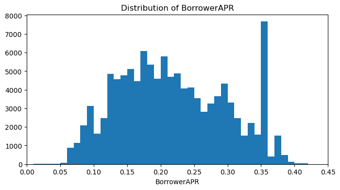

```python
#plotting distribution of BorrowerAPR on a standard scale
bins = np.arange(0, clean_loan.BorrowerAPR.max() + 0.01, 0.01)
plt.figure(figsize=(8,4))
plt.hist(data=clean_loan, x='BorrowerAPR', bins = bins )
plt.title('Distribution of BorrowerAPR')
plt.xticks(np.arange(0, 0.5, 0.05))
plt.xlim(0,0.45)
plt.xlabel('BorrowerAPR');
```

### Observation

BorrorwerAPR has a roughly bimodal distribution with the first peak being centered between 0.15 to 0.25, and a second peak which can be seen with a steep jump in frequency at the 0.35, followed by a steep decline.

### Question 2: Next, we look at the distribution of BorrowerRate and LenderYeild

### Visualization

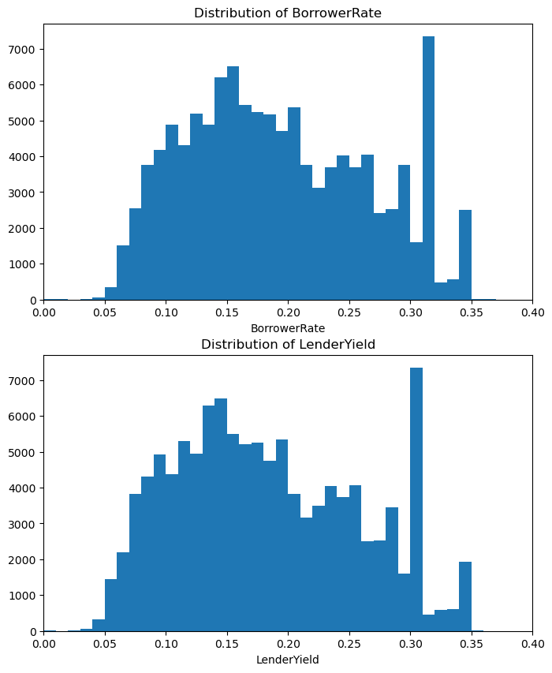

```python
plt.figure(figsize=[8,10])

#plotting distribution of IncomeRange
plt.subplot(2,1,1)
base_color=sb.color_palette()[0]
plt.hist(data=clean_loan, x='BorrowerRate', bins=bins)
plt.title('Distribution of BorrowerRate')
plt.xlim(0, 0.4)
plt.xlabel('BorrowerRate')


#plotting distribution of EmploymentStatus
plt.subplot(2,1,2)
plt.hist(data=clean_loan, x='LenderYield', bins=bins)
plt.title('Distribution of LenderYield')
plt.xlim(0, 0.4)
plt.xlabel('LenderYield');
```

### Observation

Distribution of BorrowerRate is roughly similar to that of BorrowerAPR, being bimodal with the first peak between 0.1 to 0.2, and a second peak just after 0.3. It looks like the BorrowerAPR, BorrowerRate and LenderYield are likely to be correlated.

### Question 3: What is the distribution of StatedMonthlyIncome?

#### Visualization

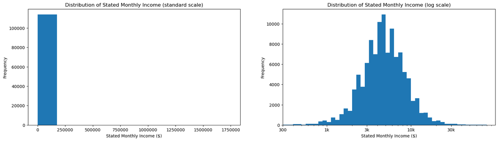

```python
plt.figure(figsize=[20, 5])

#plotting distribution of StatedMonthlyIncome on a standard scale
plt.subplot(1, 2, 1)
plt.hist(data=clean_loan, x='StatedMonthlyIncome')
plt.ticklabel_format(style='plain')
plt.xlabel('Stated Monthly Income ($)')
plt.ylabel('Frequency')
plt.title('Distribution of Stated Monthly Income (standard scale)');


#plotting distribution of StatedMonthlyIncome on a log scale
plt.subplot(1, 2, 2)
bin_max = np.log10(clean_loan.StatedMonthlyIncome.max())
x_ticks=[300, 1000, 3000, 10000, 30000]
bins = 10 ** np.arange(-1, 6, 0.05)
plt.hist(data=clean_loan, x='StatedMonthlyIncome', bins=bins)
plt.xlabel('Stated Monthly Income ($)')
plt.ylabel('Frequency')
plt.xscale('log')
plt.xlim(300, 1e5)
plt.xticks(x_ticks, ['300', '1k', '3k', '10k', '30k'])
plt.title('Distribution of Stated Monthly Income (log scale)');
```

### Observation

From the first distribution plot of StatedMonthlyIncome, we can see the data is skewed as a result of some outliers present. In the second plot, after transformation using log scale, we get a clearer view of the distribution of the monthly income stated by borrowers in their applications. Most borrowers earn between \$3000 dollars to \\$10000, there is a gradual increase to \$3k, and a gradual decrease after \\$10k in StatedMonthlyIncome among the borrowers.

### Question 4: What is the distribution of DebtToIncomeRatio?

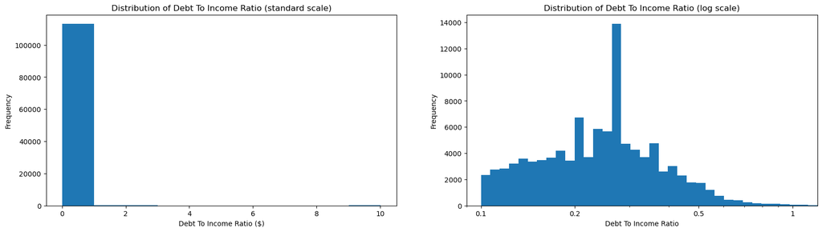

```python
plt.figure(figsize=[20,5])

#plotting distribution of DebtToIncomeRatio on a standard scale
plt.subplot(1,2,1)
plt.hist(data=clean_loan, x='DebtToIncomeRatio')
plt.ticklabel_format(style='plain')
plt.xlabel('Debt To Income Ratio ($)')
plt.ylabel('Frequency')
plt.title('Distribution of Debt To Income Ratio (standard scale)')

#plotting distribution of DebtToIncomeRatio on a log scale
plt.subplot(1,2,2)
bins = 10 ** np.arange(-1,1+0.03,0.03)
x_ticks=[0.1, 0.2, 0.5, 1]
plt.hist(data=clean_loan, x='DebtToIncomeRatio', bins=bins)
plt.xscale('log')
plt.xlim(0.09,1.2)
plt.xlabel('Debt To Income Ratio')
plt.xticks(x_ticks, x_ticks)
plt.ylabel('Frequency')
plt.title('Distribution of Debt To Income Ratio (log scale)');
```

### Observation

Borrower's DebtToincome ratio is unimodal with a peak between 0.2 and 0.5 followed a gradual decline as the value increases.

### Question 5: What is the distribution of MonthlyLoanPayment

### Visualization

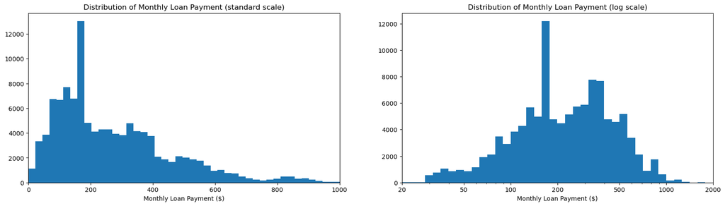

```python
plt.figure(figsize=[20,5])

# plotting distribution of MonthlyLoanPayment on a standard scale
plt.subplot(1,2,1)
plt.hist(data=clean_loan, x='MonthlyLoanPayment', bins=100)
plt.xlabel('Monthly Loan Payment ($)')
plt.title('Distribution of Monthly Loan Payment (standard scale)')
plt.xlim(0,1000)


# plotting distribution of MonthlyLoanPayment on a log scale
plt.subplot(1,2,2)
bins = 10 ** np.arange(0,np.log10(clean_loan.MonthlyLoanPayment.max()), 0.05)
x_ticks=[10,20,50,100,200,500,1000,2000, 5000,10000]
plt.hist(data=clean_loan, x='MonthlyLoanPayment', bins=bins)
plt.xscale('log')
plt.xticks(x_ticks, x_ticks)
plt.xlim(20,20e2)
plt.xlabel('Monthly Loan Payment ($)')
plt.title('Distribution of Monthly Loan Payment (log scale)');
```

### Question 6: What is the distribution of loan Term?

### Visualization

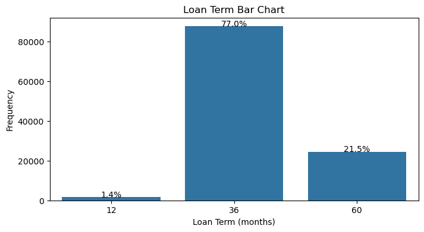

```python
plt.figure(figsize=(8,4))
# count the frequency of all non-empty rows in Term column
term_counts = clean_loan['Term'].value_counts()

# get the sum of all term_count values
n_term = clean_loan['Term'].value_counts().sum()

# plot bar chart distribution of the values in Term column
base_color = sb.color_palette()[0]
sb.countplot(data=clean_loan, x='Term', color=base_color);

# get the current tick locations and labels
locs, labels = plt.xticks()

# loop through each pair of locations and labels
for loc, label in zip(locs, labels):

    # get the text property for the label to get the correct count
    key = int(label.get_text())
    count = term_counts[key]
    pct_string = '{:0.1f}%'.format(100*count/n_term)

    # print the annotation just below the top of the bar
    plt.text(loc, count+2, pct_string, ha = 'center', color = 'black')

plt.ylabel('Frequency')
plt.xlabel('Loan Term (months)')
plt.title('Loan Term Bar Chart');
```

### Observation

Most Borrowers went for the 36 month term loans with about 77 percent of Borrower's choosing it. 21.5 percent went for 60 month term loans and only 1.4 percent went for 12 months. Which could be because 36 is more in the mid-range, as most people won't want to pay up early (12 months) and some won't want to keep paying for too long (60 months).

### Question 7: What is the distribution of LoanOriginalAmount?

### Visualization

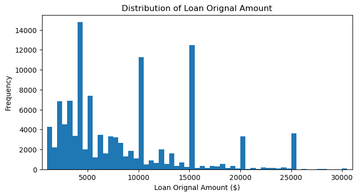

```python
plt.figure(figsize=[8,4])

bins = np.arange(1000, clean_loan.LoanOriginalAmount.max(), 500)
plt.hist(data=clean_loan, x='LoanOriginalAmount', bins=bins)
plt.xlim(500,31000)
plt.title('Distribution of Loan Orignal Amount')
plt.xlabel('Loan Orignal Amount ($)')
plt.ylabel('Frequency');
```

### Observation

The histogram above shows that the original amount for most loans were in multiples of 5000s with sudden spikes at those figures with most of the borrowers going for 15000 and below.

### Question 8: What is the distribution of IncomeRange?

### Visualization

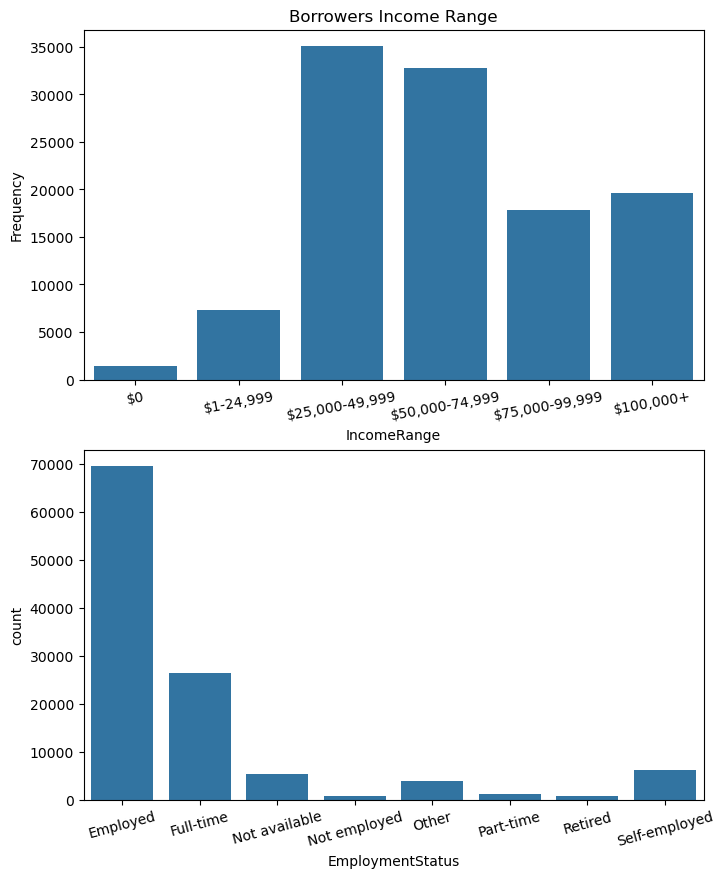

```python
plt.figure(figsize=[8,10])

#plotting distribution of IncomeRange
plt.subplot(2,1,1)
base_color=sb.color_palette()[0]
sb.countplot(data=clean_loan, x='IncomeRange', color=base_color)
plt.xticks(rotation=10)
plt.ylabel('Frequency')
plt.title ('Borrowers Income Range')


#plotting distribution of EmploymentStatus
plt.subplot(2,1,2)
sb.countplot(data=clean_loan, x='EmploymentStatus', color=base_color)
plt.xticks(rotation=15);
```

### Observation

Majority of the Borrowers are Employed and earn within \$25,000 and \\$75,000 anually with just a handfull of borrowers earn nothing at all. A good number earn high income too, ranging from \$75,000 to over \\$100,000.

### Question 8: What is the distribution of ProsperRatingNum, ProsperRatingAlpha and ProsperScore?

### Visualization

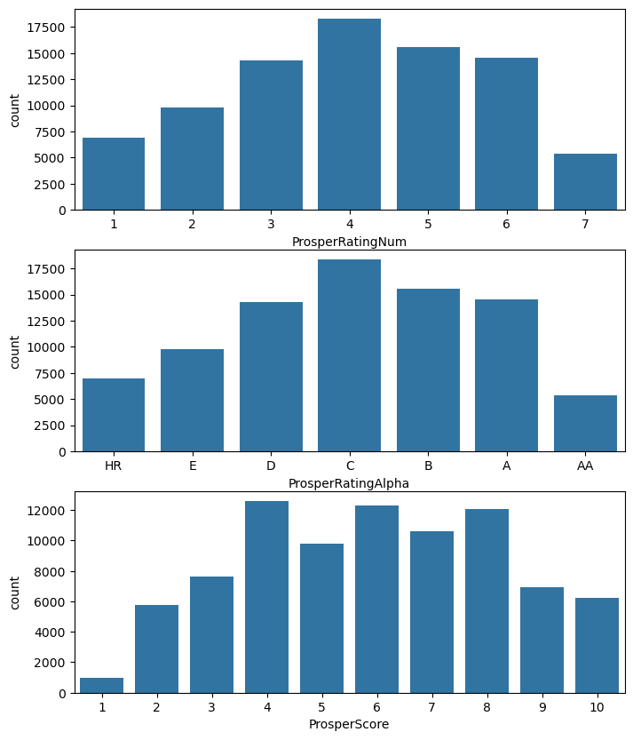

```python
# let's plot all three together to get an idea of each ordinal variable's distribution.
fig, ax = plt.subplots(nrows=3, figsize = [8,10])

sb.countplot(data = clean_loan, x = 'ProsperRatingNum', color = base_color, ax = ax[0])
sb.countplot(data = clean_loan, x = 'ProsperRatingAlpha', color = base_color, ax = ax[1])
sb.countplot(data=clean_loan, x='ProsperScore', color=base_color, ax = ax[2]);
```

### Observation

ProsperRatingNum and ProsperRating Alpha have similar distribution as their values correspond in their respective rows and columns. ProsperScore of most borrowers fall within 4 and 8 which is in the mid-level range - not too low and not too high.

### Question 9: What is the distribution of loans amonng the various Listing Categories?

### Visualization

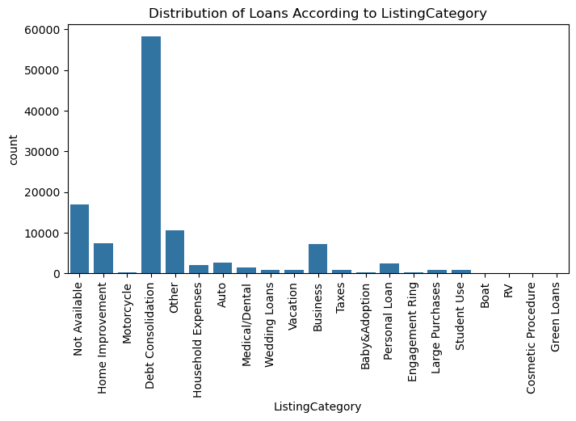

```python
plt.figure(figsize=[8,4])

# plot distribution of the entries in ListingCategory column
sb.countplot(data=clean_loan, x='ListingCategory', color=base_color)
plt.xticks(rotation=90)
plt.title('Distribution of Loans According to ListingCategory');
```

### Observation

Debt consolidation seems to be the main reason most borrowers were getting loans with a count of almost 60000. All other reasons have significantly lesser counts.

### Question 10: What is the distribution of TotalCreditLinespast7years, CurrentDelinquencies and DelinquenciesLast7Years?

### Visualization

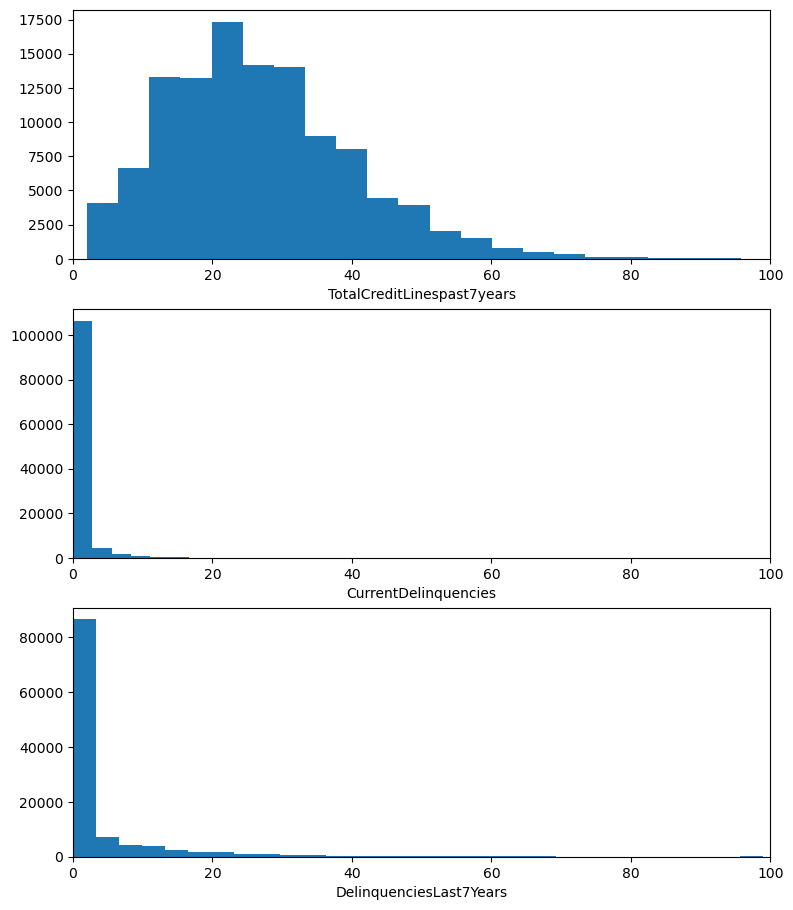

```python
# plotting the distribution on a standard scale
fig, ax = plt.subplots(nrows=3, figsize=[9,11])

variables = ['TotalCreditLinespast7years','CurrentDelinquencies','DelinquenciesLast7Years']
for i in range(len(variables)):
    var = variables[i]
    ax[i].hist(data =clean_loan, x = var, bins=30)
    ax[i].set_xlabel('{}'.format(var))
    ax[i].set_xlim(0,100)
```

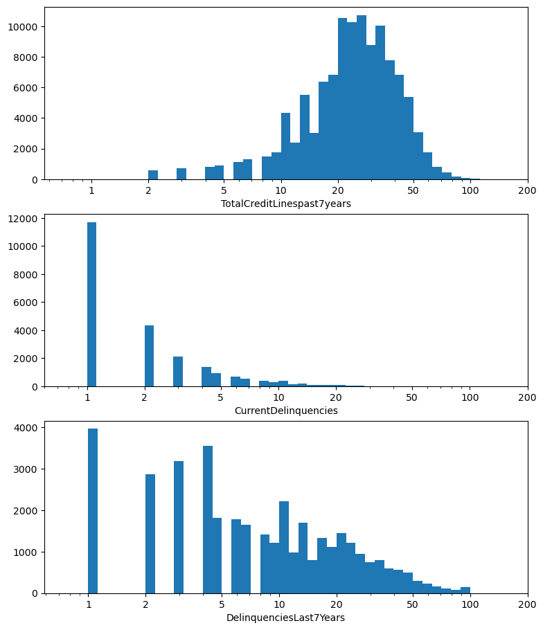

```python
# plotting the distribution on a log scale
fig, ax = plt.subplots(nrows=3, figsize=[9,11])

variables = ['TotalCreditLinespast7years','CurrentDelinquencies','DelinquenciesLast7Years']
for i in range(len(variables)):
    var = variables[i]
    bins = 10** np.arange(0, np.log(max(clean_loan[var])) + 0.05, 0.05 )
    x_ticks = [1, 2, 5, 10, 20, 50, 100, 200]
    ax[i].hist(data =clean_loan, x = var, bins=bins)
    ax[i].set_xlabel('{}'.format(var))
    ax[i].set_xscale('log')
    ax[i].set_xlim(0,200)
    ax[i].set_xticks(x_ticks, x_ticks);
```

### Observation

In TotalCreditLinespast7years, the standart scale and log scale both show at spike at 20. Majority of the borrowers, as seen in the plots of Current delinquencies and DelinquenciesLast7Years, have no current delinquencies and most of their delinquencies in the last 7 years are below 10, with just a few borrowers exceeding 10 and more delinquencies.

### Question 11: What is the distribution of the values in LoanStatus?

### Visualization

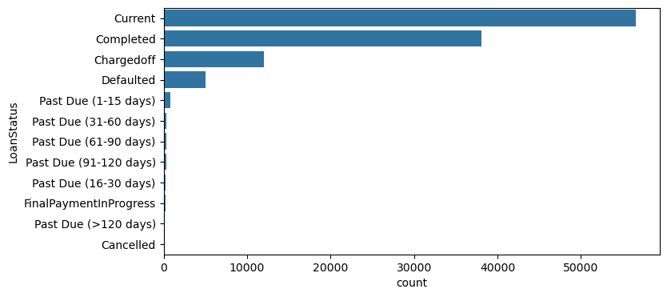

```python
plt.figure(figsize=[8,4])
freq=clean_loan.LoanStatus.value_counts()
status_order=freq.index
sb.countplot(data=clean_loan, y='LoanStatus', color=base_color, order=status_order);
```

### Observation

Loans that are currently running are more than all other categories with over 50000 currently running. Also, we can see that more borrowers complete their payments or chargedoff than those who have defaulted in their payments or are past due.

### Discuss the distribution(s) of your variable(s) of interest. Were there any unusual points? Did you need to perform any transformations?

> The BorrowerAPR variable looks to be bimodal when plotted on a standard scale and properly visualizes the entries in the column. The first peak shows most BorrowerAPR fall within 0.10 and 0.25, while the second peak was a sudden spike in the number of borrower's whose BorrowerAPR fell just above 0.35.

### Of the features you investigated, were there any unusual distributions? Did you perform any operations on the data to tidy, adjust, or change the form of the data? If so, why did you do this?

> Some of the plots among the features when plot on a standard scale were skewed, so some transformations had to be made using the log scale to get a better view of what the data was saying.

## Bivariate Exploration

### Question 1: Get a wide overview of some numeric variables in the data

### Visualization

```python
numeric_vars = ['BorrowerAPR', 'StatedMonthlyIncome', 'MonthlyLoanPayment', 'DebtToIncomeRatio',
                'CurrentDelinquencies', 'LoanOriginalAmount']
```

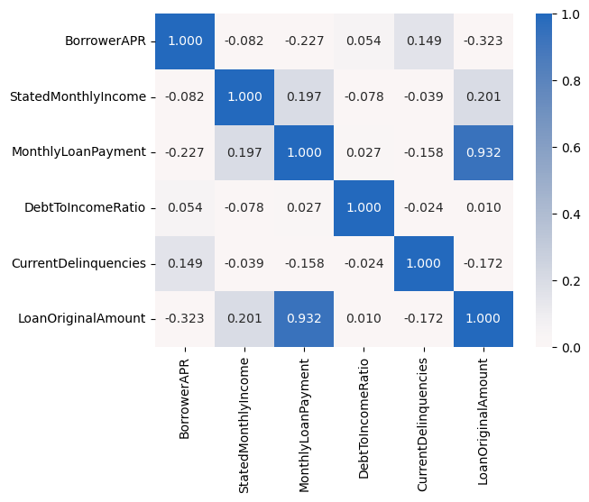

```python
sb.heatmap(clean_loan[numeric_vars].corr(), annot = True, fmt = '.3f', cmap = 'vlag_r', center = 0, vmin=0);
```

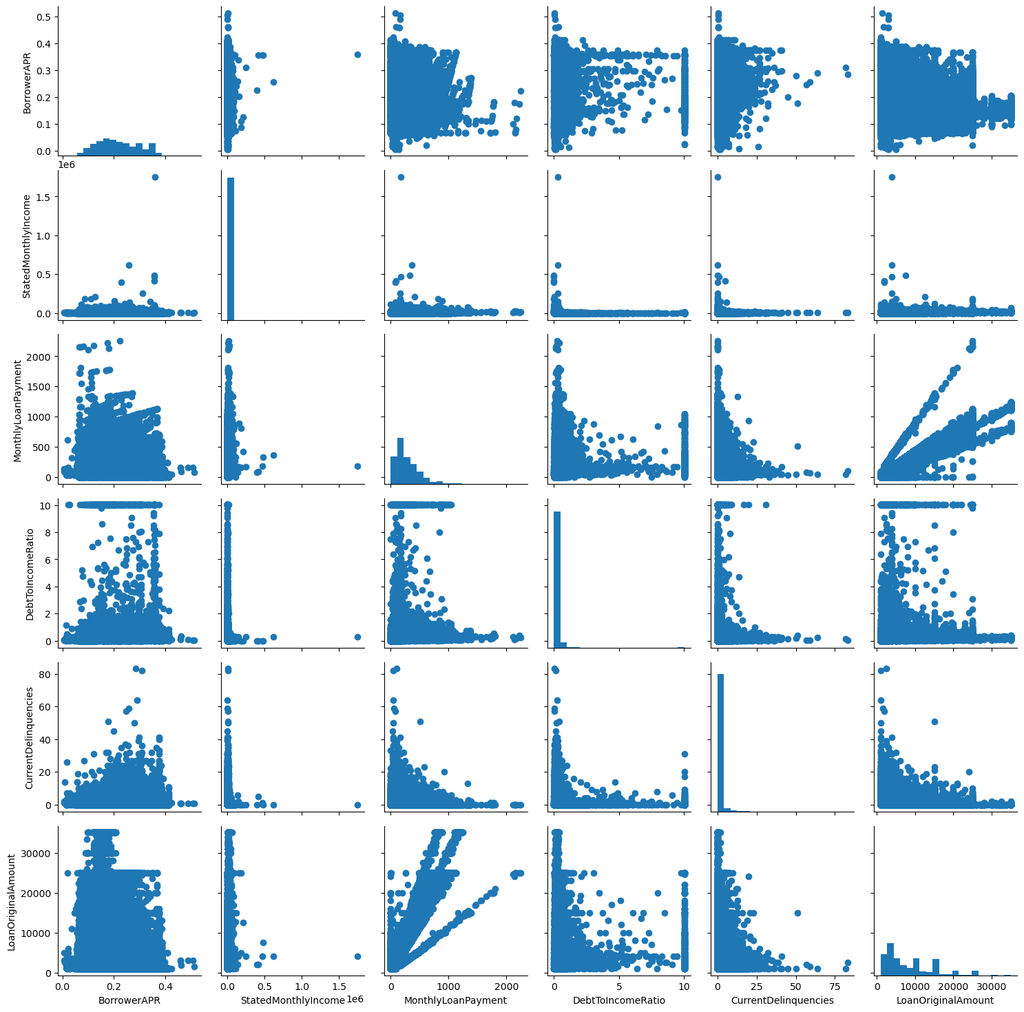

```python
# Create a scatterplot of each numeric variable against the other
g = sb.PairGrid(data=clean_loan, vars = numeric_vars)
g.map_diag(plt.hist, bins=20)
g.map_offdiag(plt.scatter);
```

### Observation

- Intuitively, we would expect to see a strong correlation between the LoanOriginalAmount and MonthlyLoanPayment. This shows that the higher the loan, the more the borrower is expected to pay monthly.
- Most borrower's StatedMonthlyIncome fall within 0-40000, although there's an outliers which will need to be addressed.
- There is a slight correlation between the number of CurrentDelinquencies a borrower has and their BorrowerAPR
- Suprisingly, it's the borrowers with the low MonthlyLoanPayments that have the most CurrentDelinquencies
- Most of the variables have outliers and need a deeper dive for a better and clearer visual representation
- Borrowers with high LoanOriginalAmount above 30000 have low APR below 20%

### Question 2: How do ProsperScore and ProsperRating relate to BorrowerAPR and LoanOriginalAmount?

### Visualization

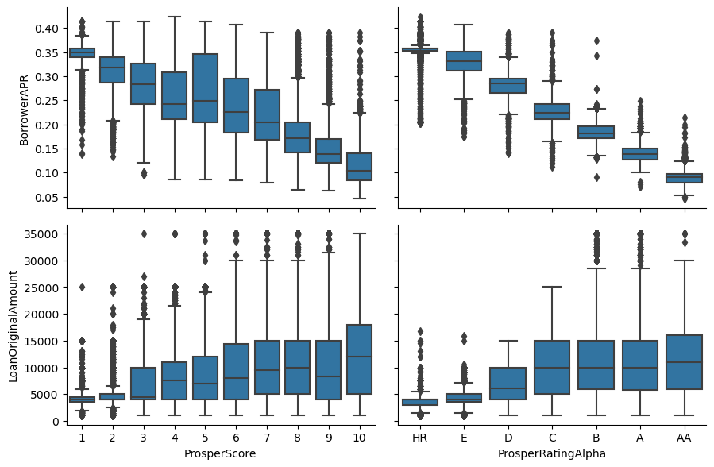

```python
x_vars = ['ProsperScore', 'ProsperRatingAlpha']
y_vars = ['BorrowerAPR', 'LoanOriginalAmount']

def boxgrid(x, y, **kwargs):
    """ Quick hack for creating box plots with seaborn's PairGrid. """
    default_color = sb.color_palette()[0]
    sb.boxplot(x, y, color = default_color)

plt.figure(figsize = [10, 10])
g = sb.PairGrid(data = clean_loan, y_vars = y_vars, x_vars = x_vars,
                size = 3, aspect = 1.5);


g.map(boxgrid)
plt.show();
```

### Observation

From both plots, it's easy to see that at highest rating and score, BorrowerAPR has the least value which is less than 10% as opposed to low rating and score which has APR going as high as 40%.

Surprisingly, people with higher Prosper ratings and score have listings for loans with higher amounts while having lower APR while those who have listings for the low loan amounts have worse ratings and higher APR.

### Question 3: What is the relationship between LoanOriginalAmount and BorrowerAPR?

### Visualization

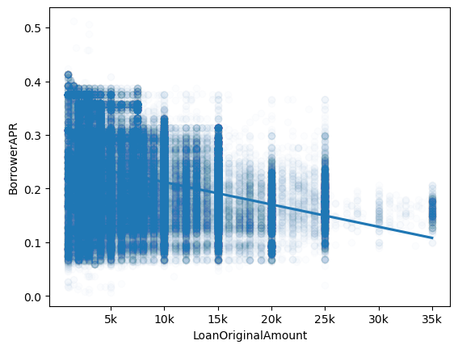

```python
# scatter plot showing BorrowerAPR vs LoanOriginal amount with a standard on both axis
sb.regplot(data=clean_loan, x='LoanOriginalAmount', y='BorrowerAPR', scatter_kws={'alpha':0.01})
x_ticks = [5000, 10000, 15000, 20000, 25000, 30000, 35000]
plt.xticks(x_ticks, ['5k','10k','15k','20k','25k','30k','35k']);
```

```python
# function to transform variables to cuberoot
def cuberoot_trans(x, inverse = False):
    """ quick function for computing cube root and cube operations """
    if not inverse:
        return x ** (1/3)
    else:
        return x ** 3
```

[figure not shown]

```python
# scatter plot showing BorrowerAPR vs LoanOriginal amount with cube root transform on the LoanOriginalAmount price
cr_LoanAmount = clean_loan['LoanOriginalAmount'].apply(cuberoot_trans)
sb.regplot(data=clean_loan, x=cr_LoanAmount, y='BorrowerAPR', scatter_kws={'alpha':0.01})
x_ticks = [10, 15, 20, 25, 30, 35]
plt.xlabel('LoanOriginalAmount')
plt.xticks(x_ticks, ['10k', '15k', '20k', '25k', '30k', '35k']);
```

### Observation

Borrower's who listings for loans with higher amounts (above \$25k), tend to have a lower BorrowerAPR (below 0.2) than those who have listings for lowers amounts.

### Question 4: Does IncomeRange have an effect on ProsperRating and BorrowerAPR?

### Visualization

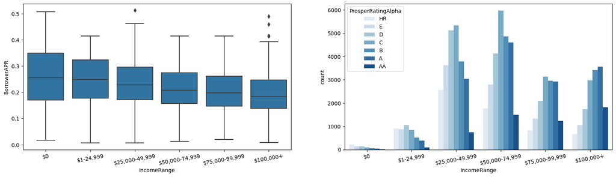

```python
plt.figure(figsize=[20,5])

plt.subplot(1,2,1)
sb.boxplot(data=clean_loan, x='IncomeRange', y='BorrowerAPR', color=base_color)
plt.xticks(rotation=10);

plt.subplot(1,2,2)
sb.countplot(data = clean_loan, x = 'IncomeRange', hue='ProsperRatingAlpha', palette='Blues')
plt.xticks(rotation=10);
```

### Observation

The average APR of most listings according to IncomeRange go from 0.2 to 0.3, with high earners having much lower average APR.

Middle class earners populate the listings and most of them have ProsperRatings between D-B with few middle class earner having an AA rating. On the other hand, we can see a higher A and AA rating for borrowers earning over \$100,000.

### Talk about some of the relationships you observed in this part of the investigation. How did the feature(s) of interest vary with other features in the dataset?

> BorrowerAPR was lower for people with higher ProsperScore and ProsperRating and the higher the borrower's IncomerRange the better their rating and score is. This shows that the high earners are more likely to get loans at lowers Annual Percentage Rates (APR).

### Did you observe any interesting relationships between the other features (not the main feature(s) of interest)?

> People who have listings of higher LoanOriginalAmount generally have better ProsperScore and ProsperRatings. Also from plotting IncomeRange against ProsperRating, we see that score and rating is better with higher income.

## Multivariate Exploration

### Question 1: How does the IncomeRange affect LoanOriginalAmount and Term

### Visualization

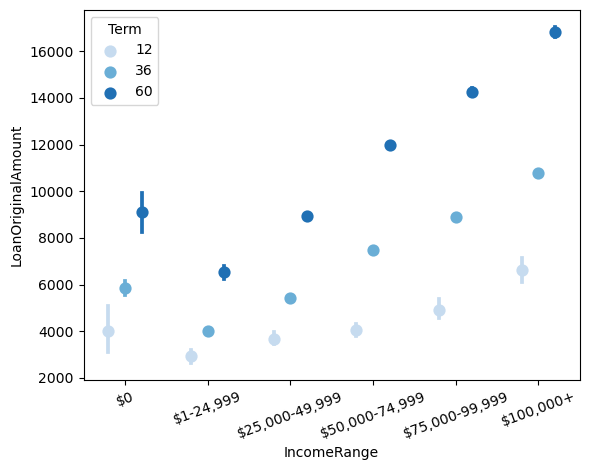

```python
# plotting a pointplot to show the amount each incomerange goes for according to term
sb.pointplot(data=clean_loan, x='IncomeRange', y='LoanOriginalAmount', hue='Term', palette='Blues',
            linestyles='', dodge=0.4)
plt.xticks(rotation=20);
```

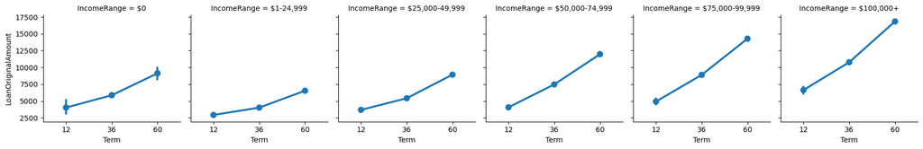

```python
# plotting each IncomeRange category in their individual axes
g = sb.FacetGrid(data=clean_loan, col='IncomeRange')
g.map(sb.pointplot, 'Term', 'LoanOriginalAmount', order=None);
```

### Question 2: Does ProsperRatingAlpha have effect on LoanOriginalAmount and BorrowerAPR

### Visualization

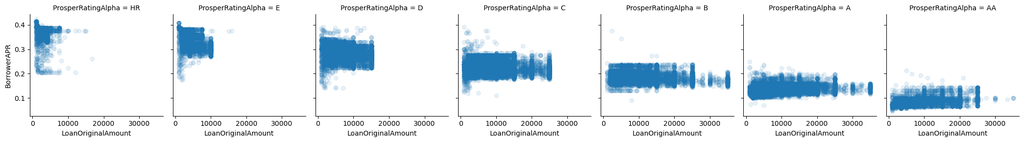

```python
# plot showing how ProsperRating relates to BorroweAPR and LoanOriginalAmount
g = sb.FacetGrid(data=clean_loan, col='ProsperRatingAlpha')
g.map(plt.scatter, 'LoanOriginalAmount', 'BorrowerAPR', alpha=0.1);
```

### Observation

As the ProsperRating Increases, the LoanOriginaAmount gradually extends to higher values while BorrowerAPR goes to lower values.

### Question 3: Does a Higher ProsperRatingAlpha and Income have any relationship with BorrowerAPR and DelinquenciesLast7Years?

### Visualization

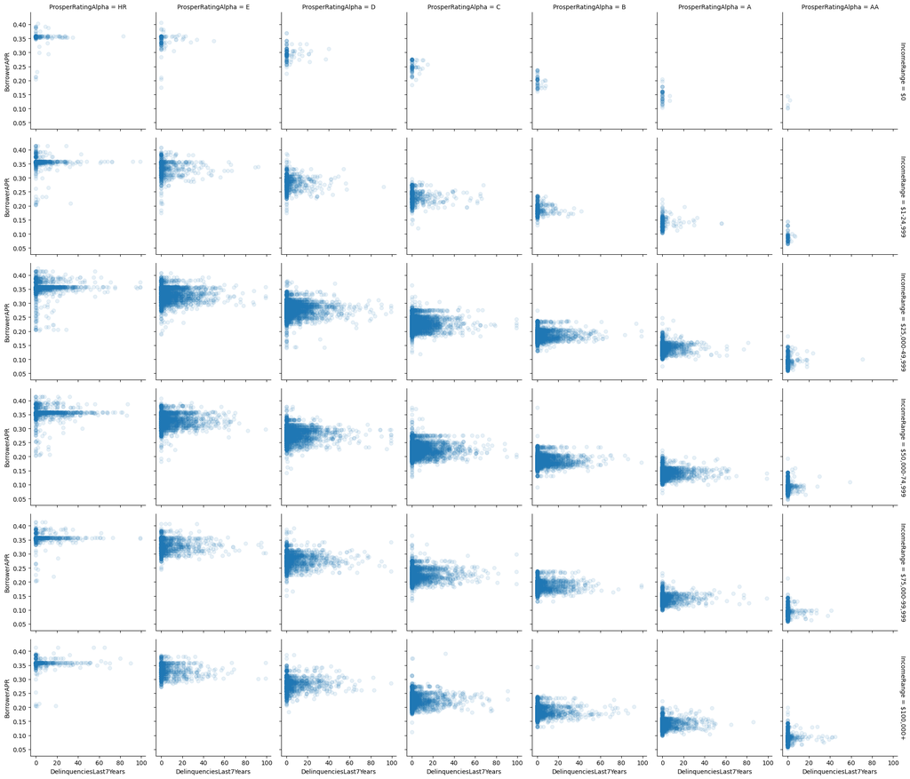

```python
# plot showing how ProsperRating relates to BorroweAPR and LoanOriginalAmount
g = sb.FacetGrid(data=clean_loan, col='ProsperRatingAlpha', row='IncomeRange', margin_titles=True)
g.map(plt.scatter, 'DelinquenciesLast7Years', 'BorrowerAPR', alpha=0.1);
```

### Observation

For each IncomeRange, we can see the number of delinquencies decrease as ProsperRatingAlpha increases. Majority of the listings fall within the mid range of ProsperRatingsAlpha (E-A). The middle class earners cover most of the population and have more people with delinquencies in the last 7 years. As IncomeRange and ProsperRatingsAlpha increase, we see a signigicant decrease in DelinquenciesLast7years and BorrowerAPR.

### Talk about some of the relationships you observed in this part of the investigation. Were there features that strengthened each other in terms of looking at your feature(s) of interest?

> I extended my investigation of BorrowerAPR to look at it's relationship with ProsperRating, LoanOriginalAmount and IncomeRanage. From the plots, we can see that as the ProsperRating and IncomeRange increase, the BorrowerAPR decreases to lesser values.

## Conclusions

It could then be safe to say that listings high income is good determinant of low APR. Borrower's with low APR are then more favorable to approve for loans as they have lesser delinquecies and earn enough to pay monthly.